# Week 12: Neural Networks — Layers, Signals, and Learning from Examples

Roozbeh Sadeghian

Last Updated: April 30, 2026

```r
library(seedhash)
gen <- SeedHashGenerator$new("ANLY530-Week12-NeuralNetworks")
MASTER_SEED <- gen$generate_seeds(1)
set.seed(MASTER_SEED)
```

**Random Seed Source:** `seedhash` package — input string: `"ANLY530-Week12-NeuralNetworks"` → seed: `743681983`

# Introduction

This week we study **neural networks**: flexible models built from many tiny calculators (**neurons**) wired together. The wiring strengths (**weights**) and small offsets (**biases**) are learned from data—much like you adjusted knobs when tuning a radio until the station came in clearly.

> **Plain English:** A neural network is a **recipe machine**. Raw ingredients (your features) go in one side. Each neuron mixes its inputs with learned weights, adds a bias, and passes the result through an **activation function**. The final layer produces a prediction (a class label, a probability, or a number). Training repeatedly adjusts weights so predictions move closer to the correct answers.

Neural networks appear under buzzwords like **deep learning** or **AI**, but the core ideas match what you already know from regression and logistic regression: combine inputs linearly, then apply a nonlinear transform. The difference is **depth** and **width**: many chained transformations let the model represent rich, curved boundaries instead of a single straight line or plane.

These beginner-friendly articles explain the same story with worked examples: GeeksforGeeks [1] and Victor Zhou’s feedforward walk-through [2]. Your lecture slides (`ANLY530Lecture13_NeuralNetworks.pptx`) anchor the course terminology.

**Learning objectives**

1. Name the parts of a network (**input / hidden / output** layers, **weights**, **biases**, **activations**).
2. Trace **forward propagation** with a small numeric example.
3. Interpret common **activation functions** and why **nonlinearity** matters (the XOR demo).
4. Connect **loss**, **gradients**, **backpropagation**, and **gradient descent** with pictures—noticing how **learning rate** changes the path.
5. Train a simple **feedforward** classifier in R (`nnet::nnet`) and compare it to **multinomial logistic regression** (`nnet::multinom`).
6. Discuss **capacity**, **overfitting**, and the **black-box** trade-off honestly.

## Required packages

```r
if (!require("pacman")) install.packages("pacman")
pacman::p_load(
  dplyr,
  tibble,
  purrr,
  ggplot2,
  nnet,
  scales,
  knitr,
  RColorBrewer
)
```

# Part 1: Vocabulary in plain English

| Term | Plain English |
| --- | --- |
| **Neuron** | One computational unit: weighted sum of inputs + bias → activation. |
| **Layer** | A row of neurons at the same depth in the network. |
| **Input layer** | Holds your measured features (often shown as nodes for bookkeeping—not always “computed”). |
| **Hidden layer** | Layers between input and output; they build intermediate representations. |
| **Output layer** | Produces the prediction (e.g., class probabilities or a numeric value). |
| **Weight** | How strongly an input influences the next neuron. Learned from data. |
| **Bias** | Lets the neuron shift its activation up or down even when inputs are zero. Also learned. |
| **Activation function** | Nonlinear squeeze/split (sigmoid, ReLU, …) that lets the network bend boundaries. |
| **Forward pass** | Data flows input → hidden → output with current weights. |
| **Loss** | A score measuring how wrong predictions are; training tries to lower it. |
| **Backpropagation** | The recipe that computes how each weight affected the loss (uses the chain rule). |
| **Epoch** | One full sweep through the training data (possibly in mini-batches). |
| **Learning rate** | Step size when updating weights; too large oscillates, too small crawls. |

# Part 2: One neuron = logistic regression’s cousin

A single neuron computes

$$z = w_1 x_1 + w_2 x_2 + \cdots + w_p x_p
+ b, \qquad a = f(z)$$

where $f$ is the activation. If $f$ is the **sigmoid** $\sigma(z) = 1/(1+e^{-z})$, one neuron is exactly **logistic regression** logic: a weighted sum followed by a probability-friendly squash into $(0,1)$.

```r
# Victor Zhou’s toy numbers: w = [0, 1], b = 4, x = [2, 3]
w <- c(0, 1)
b <- 4
x <- c(2, 3)
z <- sum(w * x) + b
sigmoid <- function(z) 1 / (1 + exp(-z))
a <- sigmoid(z)
cat(sprintf("Weighted sum z = %.4f; sigmoid(z) = %.4f\n", z, a))
```

```
## Weighted sum z = 7.0000; sigmoid(z) = 0.9991
```

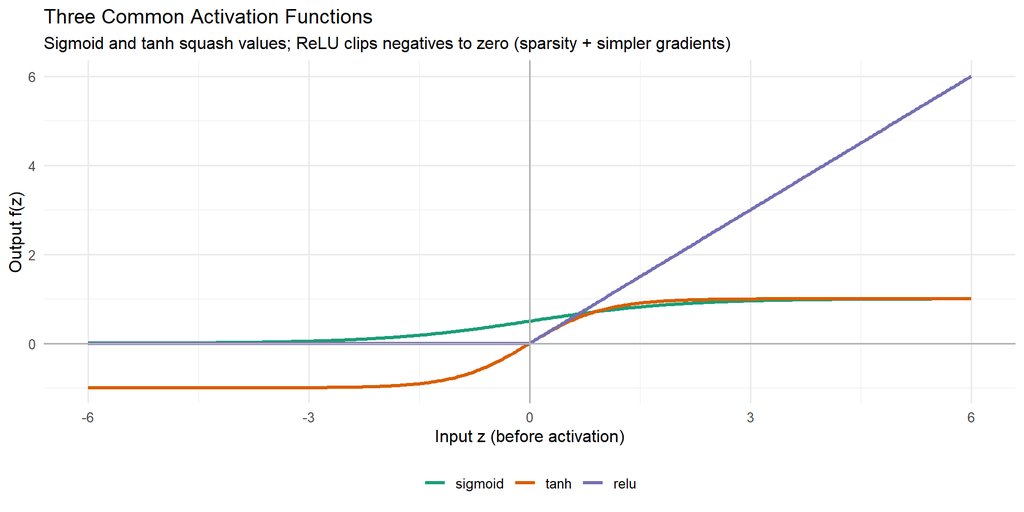

```r
zseq <- seq(-6, 6, length.out = 400)
nz <- length(zseq)
act_df <- tibble(
  zgrid = rep(zseq, 3),
  activation = factor(
    rep(c("sigmoid", "tanh", "relu"), each = nz),
    levels = c("sigmoid", "tanh", "relu")
  ),
  value = c(1 / (1 + exp(-zseq)), tanh(zseq), pmax(0, zseq))
)

ggplot(act_df, aes(x = zgrid, y = value, color = activation)) +
  geom_line(size = 1.1) +
  geom_hline(yintercept = 0, color = "grey70") +
  geom_vline(xintercept = 0, color = "grey70") +
  scale_color_brewer(palette = "Dark2") +
  labs(
    title = "Three Common Activation Functions",
    subtitle = "Sigmoid and tanh squash values; ReLU clips negatives to zero (sparsity + simpler gradients)",
    x = "Input z (before activation)",
    y = "Output f(z)",
    color = NULL
  ) +
  theme_minimal(base_size = 12) +
  theme(legend.position = "bottom")
```

> **Reading the plot:** **Sigmoid** outputs probabilities in $(0,1)$—nice for single-output classification. **Tanh** centers outputs around zero. **ReLU** ($\max(0,z)$) is piecewise linear; it trains efficiently and is the default in many deep frameworks [1].

# Part 3: Wiring neurons into a **feedforward** network

Data moves one way: input → hidden(s) → output. Below is a schematic **2 → 2 → 1** network (two inputs, two hidden neurons, one output)—the same shape Victor Zhou uses to illustrate feedforward [2].

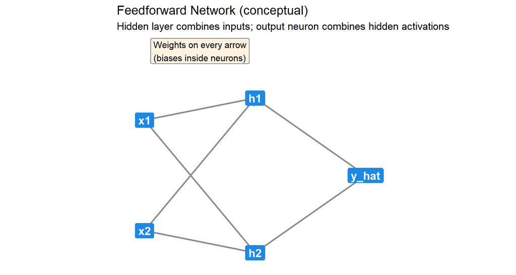

> **Hidden layers** are not mysterious—they are **feature factories**. Early layers might detect edges or keyword flags; deeper layers combine those pieces. For tabular data (rows and columns), each hidden neuron still plays the same mathematical role: weighted sum + activation.

# Part 4: Numeric forward pass (spam-keyword style)

GeeksforGeeks walks through a tiny email-spam example [1]: binary keyword features → hidden ReLU → output sigmoid. Below is the same calculation in R so you can line up code with the article’s tables.

```r
x <- c(1, 0, 1) # presence of keywords: free, win, offer
W_h <- rbind(c(0.5, -0.2, 0.3), c(0.4, 0.1, -0.5))
b_h <- c(0, 0)
z_h <- as.vector(W_h %*% x + b_h)
h <- pmax(0, z_h)

w_o <- c(0.7, 0.2)
b_o <- 0
z_o <- sum(w_o * h) + b_o
y_hat <- sigmoid(z_o)

cat("Hidden pre-activations z_h:", paste(round(z_h, 4), collapse = ", "), "\n")
```

```
## Hidden pre-activations z_h: 0.8, -0.1
```

```r
cat("Hidden activations ReLU(z_h):", paste(round(h, 4), collapse = ", "), "\n")
```

```
## Hidden activations ReLU(z_h): 0.8, 0
```

```r
cat(sprintf("Output logit z_o = %.4f; sigmoid(z_o) = %.4f\n", z_o, y_hat))
```

```
## Output logit z_o = 0.5600; sigmoid(z_o) = 0.6365
```

```r
cat(sprintf(
  "Decision at 0.5 threshold: %s\n",
  ifelse(y_hat >= 0.5, "Spam (1)", "Not spam (0)")
))
```

```
## Decision at 0.5 threshold: Spam (1)
```

This is **forward propagation**: multiply-add, activate, repeat layer by layer.

# Part 5: Why nonlinearity matters — the XOR puzzle

With **only linear boundaries**, you cannot perfectly separate XOR: points $(0,0)$ and $(1,1)$ share a label, while $(0,1)$ and $(1,0)$ share the opposite label.

```r
xor_df <- tibble(
  x1 = c(0, 0, 1, 1),
  x2 = c(0, 1, 0, 1),
  class = factor(c("A", "B", "B", "A"))
)
```

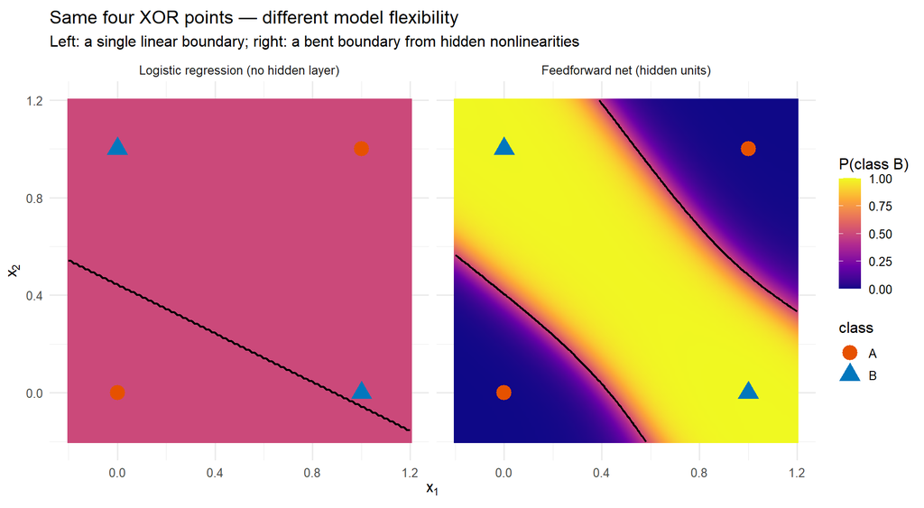

```r
grid <- as_tibble(expand.grid(
  x1 = seq(-0.2, 1.2, length.out = 120),
  x2 = seq(-0.2, 1.2, length.out = 120)
))

# Linear logistic regression boundary
glm_xor <- glm(as.numeric(class == "B") ~ x1 + x2, data = xor_df, family = binomial)
p_lin <- predict(glm_xor, grid, type = "response")
grid_lin <- grid %>% mutate(prob_B = p_lin)

set.seed(MASTER_SEED)
nn_xor <- nnet::nnet(class ~ x1 + x2, data = xor_df, size = 4, decay = 1e-4,
                     trace = FALSE, maxit = 500, linout = FALSE)
p_nn <- predict(nn_xor, grid, type = "raw")
# Column names from nnet vary by version (may be NULL or level labels); index by factor level order.
if (is.matrix(p_nn)) {
  lev <- levels(xor_df$class)
  cn <- colnames(p_nn)
  idx_B <- match("B", lev)
  if (!is.null(cn) && "B" %in% cn) {
    prob_B_nn <- p_nn[, "B", drop = TRUE]
  } else if (!is.na(idx_B) && idx_B <= ncol(p_nn)) {
    prob_B_nn <- p_nn[, idx_B, drop = TRUE]
  } else if (ncol(p_nn) == 1L) {
    prob_B_nn <- p_nn[, 1L, drop = TRUE]
  } else {
    prob_B_nn <- p_nn[, ncol(p_nn), drop = TRUE]
  }
} else {
  prob_B_nn <- as.vector(p_nn)
}
grid_nn <- grid %>% mutate(prob_B = prob_B_nn)

panels <- c(
  "Logistic regression (no hidden layer)",
  "Feedforward net (hidden units)"
)
combined <- bind_rows(
  mutate(grid_lin, panel = panels[1]),
  mutate(grid_nn, panel = panels[2])
) %>%
  mutate(panel = factor(panel, levels = panels))

xor_pts <- bind_rows(
  mutate(xor_df, panel = panels[1]),
  mutate(xor_df, panel = panels[2])
) %>%
  mutate(panel = factor(panel, levels = panels))

ggplot(combined, aes(x = x1, y = x2, fill = prob_B)) +
  geom_raster(interpolate = TRUE) +
  facet_wrap(~panel, nrow = 1) +
  geom_point(
    data = xor_pts,
    aes(x = x1, y = x2, shape = class, color = class),
    size = 5,
    inherit.aes = FALSE,
    stroke = 1.2
  ) +
  geom_contour(aes(z = prob_B), breaks = 0.5, color = "black", size = 0.8) +
  scale_fill_viridis_c(option = "C", limits = c(0, 1), name = "P(class B)") +
  scale_color_manual(values = c(A = "#E65100", B = "#0277BD")) +
  scale_shape_manual(values = c(A = 16, B = 17)) +
  coord_fixed() +
  labs(
    title = "Same four XOR points — different model flexibility",
    subtitle = "Left: a single linear boundary; right: a bent boundary from hidden nonlinearities",
    x = expression(x[1]),
    y = expression(x[2])
  ) +
  theme_minimal(base_size = 12) +
  theme(legend.position = "right")
```

> **Takeaway:** Stack neurons + nonlinear activations and boundaries become **curved**. Depth isn’t magic—it’s structured flexibility you must regularise so it doesn’t memorise noise [1].